# **Finding the most efficient portfolio**

Now with the help of our computer, we will consider **ALL** the different sets of weights possible our stocks *to reach a portfolio that has the highest Sharpe ratio*. That is, among these random portfolios, I would like to find the most efficient ones (According to Sharpe). This notebook is a sequel to previous notes where I am using a dataset of 14 securities. Thus I suggest you read the previous notes to fully understand what is going on here.

To do so, we need to give a series of instructions to the computer to:

1. Choose a random set of weights each time
2. Create a portfolio with them
3. Measure the risk
4. Calculate the Sharpe ratio
5. Finally, save it in a list so it can be compared with all other portfolios made through the same process

```python
# This is the package for downloading US stock data
import yfinance as yf, pandas as pd, numpy as np, datetime as dt
import matplotlib as mpl, matplotlib.pyplot as plt
```

## *Importing an Excel File*

*Note: the Excel file and this Jupyter notebook should be located in the same folder. Otherwise, the process of importing the excel file may require extra steps of code*.

```python
main_data = pd.read_excel('returns_cleaned.xlsx', index_col='Date')


# also drop the the columns (Port_1 & Risk Fee) since I do not need them in my task here
main_data = main_data.drop(columns=['Port_1', 'Risk Free'])

main_data.head()
```

| Date | AMZN | BA | CVX | DIS | GOLD | HSY | INTC | K | KO | M | MMM | MSFT | NVDA | ^W5000 |
| --- | --- | --- | --- | --- | --- | --- | --- | --- | --- | --- | --- | --- | --- | --- |
| 2000-02 | 0.066796 | -0.169944 | -0.106876 | -0.063683 | -0.003817 | 0.033823 | 0.142136 | 0.043815 | -0.153428 | -0.118619 | -0.058078 | -0.086845 | 0.726813 | 0.021192 |
| 2000-03 | -0.027223 | 0.027196 | 0.248125 | 0.213236 | -0.038314 | 0.115744 | 0.167938 | 0.028577 | -0.034704 | 0.151618 | 0.010757 | 0.188811 | 0.320068 | 0.058114 |
| 2000-04 | -0.176306 | 0.049587 | -0.079108 | 0.057576 | 0.071714 | -0.066667 | -0.038844 | -0.058252 | 0.010433 | -0.195266 | -0.021877 | -0.343529 | 0.054929 | -0.052775 |
| 2000-05 | -0.124575 | -0.015748 | 0.085904 | -0.032951 | 0.078067 | 0.140109 | -0.016757 | 0.252577 | 0.129630 | 0.132353 | -0.010101 | -0.103047 | 0.280505 | -0.036091 |
| 2000-06 | -0.248383 | 0.074325 | -0.076026 | -0.080000 | 0.008687 | -0.060264 | 0.072445 | -0.012356 | 0.076112 | -0.123377 | -0.025796 | 0.278721 | 0.113911 | 0.043327 |

```python
main_data.describe()
```

|  | AMZN | BA | CVX | DIS | GOLD | HSY | INTC | K | KO | M | MMM | MSFT | NVDA | ^W5000 |
| --- | --- | --- | --- | --- | --- | --- | --- | --- | --- | --- | --- | --- | --- | --- |
| count | 287.000000 | 287.000000 | 287.000000 | 287.000000 | 287.000000 | 287.000000 | 287.000000 | 287.000000 | 287.000000 | 287.000000 | 287.000000 | 287.000000 | 287.000000 | 287.000000 |
| mean | 0.021791 | 0.012425 | 0.009857 | 0.006993 | 0.008019 | 0.011105 | 0.006905 | 0.006957 | 0.006123 | 0.010586 | 0.007103 | 0.012066 | 0.037451 | 0.005589 |
| std | 0.129926 | 0.095598 | 0.069003 | 0.076331 | 0.114357 | 0.057571 | 0.097305 | 0.049571 | 0.050752 | 0.129830 | 0.060703 | 0.081098 | 0.174042 | 0.045973 |
| min | -0.411552 | -0.454664 | -0.214625 | -0.267794 | -0.381056 | -0.177236 | -0.444732 | -0.138636 | -0.172743 | -0.628874 | -0.157037 | -0.343529 | -0.486551 | -0.177406 |
| 25% | -0.048718 | -0.042805 | -0.029320 | -0.034121 | -0.065293 | -0.025150 | -0.047196 | -0.021066 | -0.024001 | -0.061762 | -0.028618 | -0.037006 | -0.054362 | -0.021149 |
| 50% | 0.021677 | 0.015899 | 0.008623 | 0.005748 | 0.007592 | 0.008660 | 0.007672 | 0.009468 | 0.008546 | 0.011221 | 0.010560 | 0.017244 | 0.030835 | 0.011240 |
| 75% | 0.087617 | 0.070993 | 0.046279 | 0.050941 | 0.072783 | 0.044363 | 0.062263 | 0.035843 | 0.038312 | 0.077280 | 0.039402 | 0.055028 | 0.122156 | 0.034368 |
| max | 0.621776 | 0.459312 | 0.269666 | 0.248734 | 0.426362 | 0.275952 | 0.337429 | 0.252577 | 0.141928 | 0.644122 | 0.213949 | 0.407781 | 0.826237 | 0.133806 |

```python
stock_names = [x for x in main_data.columns]
stock_means = np.array([main_data[x].mean() for x in stock_names]).T
stock_cov = np.array(main_data[stock_names].cov())
dataset_columns = stock_names + ['Port_Return', 'Port_Risk', 'Port_Sharpe']
r_f = 0.005
no_stocks = len(stock_names)
```

```python
main_list = []

for i in range(10000000):

    weight = np.array([np.random.random_sample() for x in stock_names])
    weight /= np.sum(weight)
    entry = [weight.dot(stock_means)]
    entry.append(weight.dot(stock_cov).dot(weight.T)**0.5)
    sharpe = (entry[-2] - r_f ) / entry[-1]
    entry.append(sharpe)
    main_list.append(np.append(weight, entry))

print('done!!!')
```

```
done!!!
```

```python
main_matrix = np.vstack(main_list)

main_matrix[:7]
```

```
array([[0.08952249, 0.1237281 , 0.09806072, 0.08110084, 0.0997132 ,
        0.08158651, 0.08989499, 0.00660169, 0.0151624 , 0.10605358,
        0.05307233, 0.06608257, 0.0041403 , 0.08528027, 0.0104156 ,
        0.05132228, 0.10552137],
       [0.05307114, 0.09823329, 0.02633822, 0.13302875, 0.06579368,
        0.10195316, 0.13875912, 0.07471172, 0.03135454, 0.00455951,
        0.02169596, 0.05511066, 0.07023474, 0.1251555 , 0.01109369,
        0.04957423, 0.12292059],
       [0.04419427, 0.12961178, 0.01164222, 0.13435415, 0.13914584,
        0.10364673, 0.09756549, 0.03148035, 0.06038125, 0.14337519,
        0.04890231, 0.02915401, 0.01648726, 0.01005915, 0.0100475 ,
        0.05137652, 0.09824526],
       [0.08085281, 0.00766668, 0.00561845, 0.03279166, 0.00033228,
        0.11513434, 0.01633928, 0.15791356, 0.13349173, 0.0208246 ,
        0.03281222, 0.13272392, 0.11264784, 0.15085063, 0.01256861,
        0.04753374, 0.15922604],
       [0.02992966, 0.01160897, 0.0241734 , 0.14091895, 0.0794554 ,
        0.01960431, 0.11477198, 0.07319995, 0.18034245, 0.11808549,
        0.01886189, 0.13651088, 0.0375537 , 0.01498296, 0.00980218,
        0.04965786, 0.09670536],
       [0.06936717, 0.07466782, 0.06707473, 0.11496441, 0.07953203,
        0.11240064, 0.01256041, 0.02881488, 0.03830221, 0.10925284,
        0.07255171, 0.04336411, 0.09058646, 0.08656057, 0.01238356,
        0.05171059, 0.14278626],
       [0.02401006, 0.04123624, 0.09985102, 0.0852718 , 0.03947427,
        0.08406158, 0.14704075, 0.01334256, 0.12612358, 0.00170426,
        0.11442047, 0.12646769, 0.02193327, 0.07506246, 0.0093441 ,
        0.04506295, 0.09640072]])
```

```python
efficient_port = pd.DataFrame(main_matrix[1:], columns = dataset_columns)

efficient_port.describe().apply(lambda s: s.apply('{0:.5f}'.format))
```

|  | AMZN | BA | CVX | DIS | GOLD | HSY | INTC | K | KO | M | MMM | MSFT | NVDA | ^W5000 | Port_Return | Port_Risk | Port_Sharpe |
| --- | --- | --- | --- | --- | --- | --- | --- | --- | --- | --- | --- | --- | --- | --- | --- | --- | --- |
| count | 9999999.00000 | 9999999.00000 | 9999999.00000 | 9999999.00000 | 9999999.00000 | 9999999.00000 | 9999999.00000 | 9999999.00000 | 9999999.00000 | 9999999.00000 | 9999999.00000 | 9999999.00000 | 9999999.00000 | 9999999.00000 | 9999999.00000 | 9999999.00000 | 9999999.00000 |
| mean | 0.07141 | 0.07143 | 0.07146 | 0.07139 | 0.07143 | 0.07145 | 0.07143 | 0.07142 | 0.07143 | 0.07143 | 0.07143 | 0.07141 | 0.07145 | 0.07142 | 0.01164 | 0.05068 | 0.13037 |
| std | 0.04116 | 0.04117 | 0.04117 | 0.04116 | 0.04118 | 0.04115 | 0.04118 | 0.04117 | 0.04118 | 0.04115 | 0.04118 | 0.04117 | 0.04117 | 0.04116 | 0.00131 | 0.00426 | 0.01932 |
| min | 0.00000 | 0.00000 | 0.00000 | 0.00000 | 0.00000 | 0.00000 | 0.00000 | 0.00000 | 0.00000 | 0.00000 | 0.00000 | 0.00000 | 0.00000 | 0.00000 | 0.00728 | 0.03525 | 0.05057 |
| 25% | 0.03704 | 0.03705 | 0.03706 | 0.03701 | 0.03702 | 0.03710 | 0.03703 | 0.03704 | 0.03703 | 0.03706 | 0.03703 | 0.03701 | 0.03706 | 0.03706 | 0.01067 | 0.04770 | 0.11688 |
| 50% | 0.07141 | 0.07142 | 0.07148 | 0.07138 | 0.07141 | 0.07145 | 0.07143 | 0.07141 | 0.07143 | 0.07142 | 0.07143 | 0.07139 | 0.07145 | 0.07141 | 0.01164 | 0.05047 | 0.13175 |
| 75% | 0.10352 | 0.10355 | 0.10358 | 0.10348 | 0.10357 | 0.10354 | 0.10356 | 0.10354 | 0.10355 | 0.10353 | 0.10355 | 0.10355 | 0.10357 | 0.10352 | 0.01258 | 0.05341 | 0.14450 |
| max | 0.30460 | 0.42600 | 0.35769 | 0.33866 | 0.36738 | 0.32222 | 0.34830 | 0.35433 | 0.32917 | 0.31468 | 0.39217 | 0.33261 | 0.32792 | 0.38799 | 0.02018 | 0.08534 | 0.20671 |

```python
efficient_port.head()
```

|  | AMZN | BA | CVX | DIS | GOLD | HSY | INTC | K | KO | M | MMM | MSFT | NVDA | ^W5000 | Port_Return | Port_Risk | Port_Sharpe |
| --- | --- | --- | --- | --- | --- | --- | --- | --- | --- | --- | --- | --- | --- | --- | --- | --- | --- |
| 0 | 0.053071 | 0.098233 | 0.026338 | 0.133029 | 0.065794 | 0.101953 | 0.138759 | 0.074712 | 0.031355 | 0.004560 | 0.021696 | 0.055111 | 0.070235 | 0.125156 | 0.011094 | 0.049574 | 0.122921 |
| 1 | 0.044194 | 0.129612 | 0.011642 | 0.134354 | 0.139146 | 0.103647 | 0.097565 | 0.031480 | 0.060381 | 0.143375 | 0.048902 | 0.029154 | 0.016487 | 0.010059 | 0.010047 | 0.051377 | 0.098245 |
| 2 | 0.080853 | 0.007667 | 0.005618 | 0.032792 | 0.000332 | 0.115134 | 0.016339 | 0.157914 | 0.133492 | 0.020825 | 0.032812 | 0.132724 | 0.112648 | 0.150851 | 0.012569 | 0.047534 | 0.159226 |
| 3 | 0.029930 | 0.011609 | 0.024173 | 0.140919 | 0.079455 | 0.019604 | 0.114772 | 0.073200 | 0.180342 | 0.118085 | 0.018862 | 0.136511 | 0.037554 | 0.014983 | 0.009802 | 0.049658 | 0.096705 |
| 4 | 0.069367 | 0.074668 | 0.067075 | 0.114964 | 0.079532 | 0.112401 | 0.012560 | 0.028815 | 0.038302 | 0.109253 | 0.072552 | 0.043364 | 0.090586 | 0.086561 | 0.012384 | 0.051711 | 0.142786 |

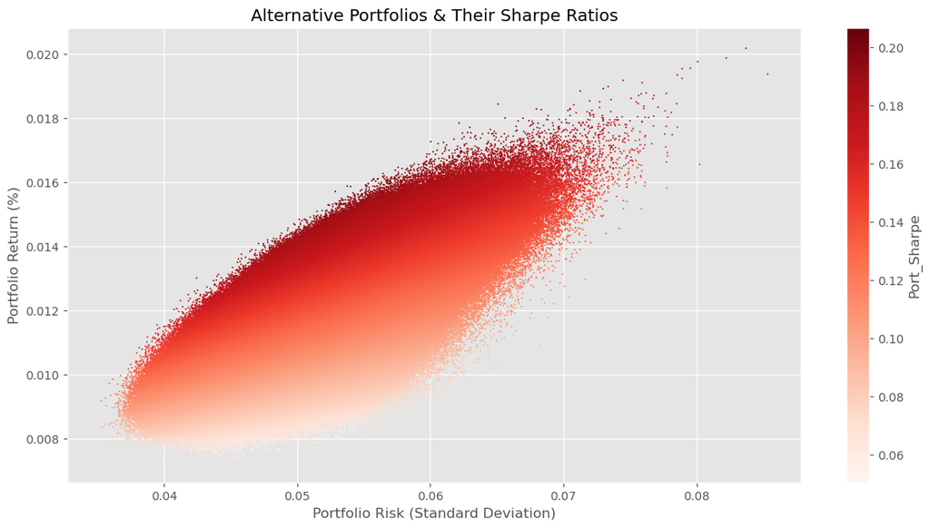

```python
with plt.style.context('ggplot'):

    efficient_port.plot.scatter(x='Port_Risk',
                                y = 'Port_Return',
                                c= 'Port_Sharpe',
                                s=0.75,
                                colormap='Reds',
                                title= 'Alternative Portfolios & Their Sharpe Ratios',
                                xlabel= "Portfolio Risk (Standard Deviation)",
                                ylabel= 'Portfolio Return (%)',
                                figsize=(14,7))


plt.show()
```

```python
# What is the highest Sharpe ratio in this table?
efficient_port['Port_Sharpe'].max()
```

```
0.2067120020682262
```

```python
efficient_port['Port_Sharpe'].idxmax()
```

```
8835253
```

```python
efficient_port.iloc[8835253]
```

```
AMZN           0.184954
BA             0.038137
CVX            0.005322
DIS            0.000620
GOLD           0.078891
HSY            0.234023
INTC           0.005338
K              0.014769
KO             0.041534
M              0.018769
MMM            0.077062
MSFT           0.057378
NVDA           0.215487
^W5000         0.027718
Port_Return    0.017850
Port_Risk      0.062163
Port_Sharpe    0.206712
Name: 8835253, dtype: float64
```

```python
# What are stock the weights for this highest Sharpe ratio?
efficient_port.iloc[efficient_port['Port_Sharpe'].idxmax()]
```

```
AMZN           0.184954
BA             0.038137
CVX            0.005322
DIS            0.000620
GOLD           0.078891
HSY            0.234023
INTC           0.005338
K              0.014769
KO             0.041534
M              0.018769
MMM            0.077062
MSFT           0.057378
NVDA           0.215487
^W5000         0.027718
Port_Return    0.017850
Port_Risk      0.062163
Port_Sharpe    0.206712
Name: 8835253, dtype: float64
```